# Course Datasets

POLS 2140: Introduction to Political Analysis

Dr. Sarah Dreier

## Reading Prompt

Answer **both** questions:

- What is one thing you learned about survey data from today’s chapter?
- Which survey (ANES or WVS) do you think you will use and why?

## Announcements

- **Office Hours** this week (Dr. Dreier): Friday 12:30-2:30
- **Consequences for late work?**

## Lecture objectives

- Introduce the components of a survey dataset
- Select possible variables of interest
- Brainstorm IV/DV pairings
  - You should all leave with an independent variable (“cause”) and a dependent variable (“outcome”)!

# Course Datasets

## Option 1: American National Election Survey (ANES)

[figure not shown]

About the survey

- **Year:** 2024 Time Series Study
- **Population:** U.S. eligible voters
- **Sample:** 5,521 pre-election; 4,964 also post-election
- **What it covers:** US voters’ attitudes and perspectives about politics, policies, and pressing social issues.
- Read about it [here](https://electionstudies.org/data-center/2024-time-series-study/)!

## Option 1: American National Election Survey (ANES)

[figure not shown]

Survey components and terms

- **Unit of analysis:** Individual respondents
- **Observations**: Each individual person interviewed (“respondent”) → *rows*
  - 5,521 respondents ($n=5521$)
- **Variables**: Each specific question asked → *columns*
  - +1,000 variables!
  - **Variable label:** What each survey question is called/labeled
    - V240001 – V241751: Pre-election survey questions
    - V242002 – V242640: Post-election survey questions
  - **Variable value:** How each person responded to each question

## Variable V241177: Political Ideology

*“Where would you place yourself on this scale, or haven’t you thought much about this?”*

1: Extremely liberal; 4: Moderate; middle of the road; 7: Extremely conservative

```r
suppressMessages(library(tidyverse))

ideology <- tibble(
  score = factor(c("1", "2", "3", "4", "5", "6", "7", "DK"),
                 levels = c("1", "2", "3", "4", "5", "6", "7", "DK")),
  n = c(250, 819, 543, 1187, 594, 1030, 309, 719)
) |>
  uncount(n)

ggplot(ideology, aes(x = score, fill = score == "DK")) +
  geom_bar(color = "white", show.legend = FALSE) +
  scale_fill_manual(values = c(`TRUE` = "#999999", `FALSE` = "#107895")) +
  labs(
    x = "Ideology (1–7; DK = haven't thought much)",
    y = "Respondents"
  ) +
  theme_minimal(base_size = 11) +
  theme(
    panel.grid.minor = element_blank(),
    plot.background = element_rect(fill = "transparent", color = NA),
    panel.background = element_rect(fill = "transparent", color = NA)
  )
```

**Note:** This is a **self-report** measure — it captures how people *label* themselves, not necessarily their positions on specific policies.

[figure not shown]

Real 2024 pre-election marginals for `V241177` (N = 5,521 total; 5,451 substantive responses after excluding 70 refused/error; unweighted).

## Other available topics (ANES)

- **Presidential approval** → `V241134` Do you approve/disapprove of the President’s handling of the job?
- **Gender attitudes** → `V242212` — How important is it that more women get elected to political office?
- **Climate change** → `V242322` — Do you favor/oppose increased regulation on greenhouse emissions?
- **Inflation / cost of living** → `V242173` — How important is the issue: cost of living
- **Immigration** → `V241267` — Should federal spending on tightening border security to prevent illegal immigration be increased, decreased, or kept the same?
- **Gun control** → `V242326` — Do you favor/oppose background checks for gun purchases?

These are not the only option for each topic, and not the only topics available!

Source: [ANES 2024 Full Release codebook](https://sda.berkeley.edu/sdaweb/docs/anes2024full/DOC/hcbkh01.htm).

## Option 2: World Values Survey (WVS)

[figure not shown]

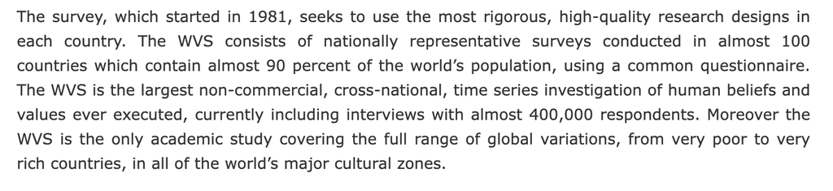

## Option 2: World Values Survey (WVS)

[figure not shown]

Survey components and terms

- **Unit of analysis:** Individual respondents
- **Observations**: Each individual person interviewed (“respondent”) → *rows*
  - 94,278 respondents ($n=94278$)
- **Variables:** each specific question asked → *columns*
  - 606 variables!
  - **Variable label:** What each survey question is called/labeled
    - Q1 – Q294B: Survey questions
    - A_YEAR, B_COUNTRY, etc: Demographics and identifiers
  - **Variable value:** How each person responded to each question

## Variables Q243 & Q249: Essential features to a democracy

*How essential to a democracy is it that: People choose their leaders in free elections (Q243) or that: Women have the same rights as men (Q249)?*

1 = Not at all essential to democracy; 10 = definitely essential to democracy

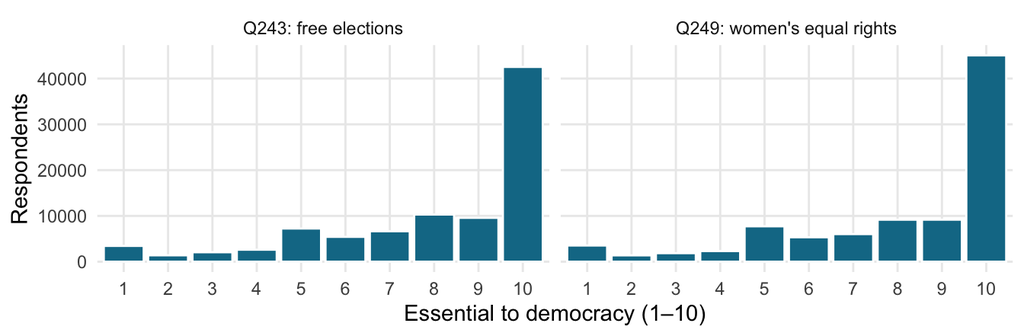

This is a **self-report** measure. It captures what people *say* democracy requires, not how their country is actually run.

Source: [WVS Wave 7 Master Questionnaire](https://www.worldvaluessurvey.org/WVSDocumentationWV7.jsp), items Q243 & Q249.

## Q243 & Q249: US vs. Germany

Percent of each country’s respondents at each point on the 1–10 “essential to democracy” scale.

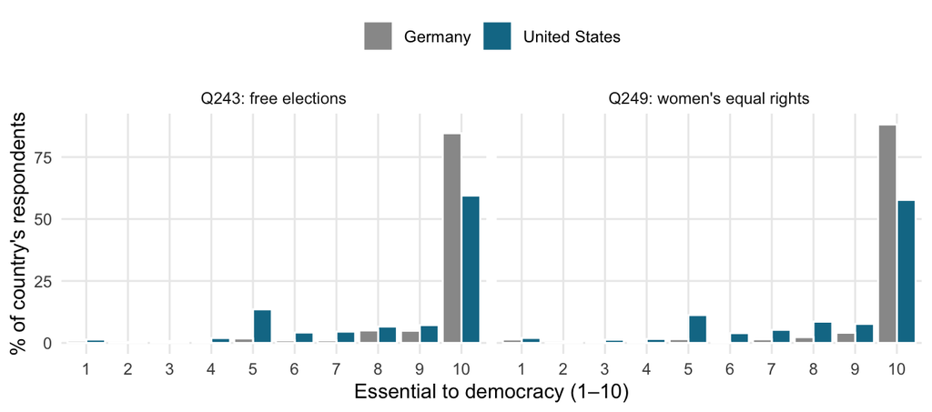

WVS Wave 7. US n ≈ 2,550 valid; Germany n ≈ 1,520 valid. Unweighted. Germans rate both items closer to “definitely essential” (mean ≈ 9.6 vs US ≈ 8.5); note the US cluster at the “5” midpoint.

## More attitudes about democracy (and democratic backsliding)

- **Q238** — support for “having a democratic political system” (direct democracy-support item)
- **Q235** — support for “a strong leader who does not have to bother with parliament and elections” (classic authoritarian-preference item)
- **Q237** — support for “having the army rule”
- **Q243** — is “people choose their leaders in free elections” essential to democracy?
- **Q245** — is “the army takes over when government is incompetent” essential to democracy? (a high score here is itself a red flag — endorsing a coup as *democratic*)

**Other WVS Wave 7 topics include**: Trust & social capital, economic satisfaction, gender attitudes & stereotypes, religion, happiness & well-being. Source: [WVS Wave 7 documentation](https://www.worldvaluessurvey.org/WVSContents.jsp?CMSID=Documentation).

# Exploring the available variables

## Your topic(s) of interest

**What topic would you like to analyze in this class?**

- Option 1: Are you interested in explaining how something about your topic came about?
  - → Your topic is your **outcome** / **dependent variable**.
  - What are some **independent variable** factors that you think might cause or influence your topic?
- Option 2: Are you interested in explaining what your topic might cause or influence?
  - → Your topic is your **cause** / **independent variable**.
  - What are some factors or circumstances that you think your topic might cause or influence?

## Using surveys

- **What IS represented in surveys?**
  - People’s reported **identities**
  - People’s reported **circumstances**
  - People’s reported **perceptions, opinions** (e.g., about policies, governments, social issues, etc.) or **behavior**
- **What IS NOT represented in surveys?**
  - Existence or content of policies
  - Frequencies of certain behaviors
  - Impact of policies (beyond people’s opinions)
  - A geography’s demographic information
  - Changes over time

## Let’s find some variables about your topic!

**In-class exercise:** Open your codebook (Canvas or QR codes). Search for 2–3 survey questions related to your topic of interest. I recommend using your computers keyword search function (Ctrl/Cmd-F).

[figure not shown]

**ANES — full codebook**  
question wording + response categories

[figure not shown]

**ANES — variable list**  
quick names + one-line labels

[figure not shown]

**WVS Wave 7 documentation**  
questionnaire + codebook downloads

**ANES:** use “Find” (Ctrl/Cmd-F) on the variable list, then look up the `Vxxxxxx` names in the codebook. **WVS:** the questionnaire is organized in thematic blocks — find your block, then its `Qxxx` items.

## Workshop your approach

- Your political topic of interest
- 2-3 survey variables that begin to capture your topic of interest. What do you like about the variable(s)? What are some limitations to the variable(s)?
- **Think about your topic/variable as an outcome (DV).** What might be good IVs captured in the survey data that influence your topic? *When in doubt, what makes for a great IV?* A respondent’s characteristics that likely pre-date their social/policy opinions.
- **Think about your topic/variable as a cause of something else (IV).** What might be good DVs captured in the survey that are influenced by your topic?
- Develop a research question you have about your topic, based on the variables in the survey. Ex: *Does gender shape people’s attitudes toward climate change?*
- Record your working IV/DV in the class [Google drive](https://docs.google.com/spreadsheets/d/17W2_PpL2DCbcXn6pim2iVZCAcC7JBVsnrd_Cf4BaUrU/edit?gid=0#gid=0) (Modules -> Course exercises -> Project IV/DV)

## For Thursday:

Assigned reading for our next class meeting:

- Kellstedt et al. (2022, Ch. 2, pp. 29–38), “The Art of Theory Building”
- Using [Google Scholar](https://scholar.google.com/), identify and skim one academic article related to your topic of interest.

**Begin your Final Research Analysis Task 1: Theory and Hypothesis.** Full schedule on the [syllabus](https://skdreier.github.io/POLS2140/).

# Other survey features

## Using surveys: what is a battery?

What is a **battery**? A set of related questions asked together on the same response scale.

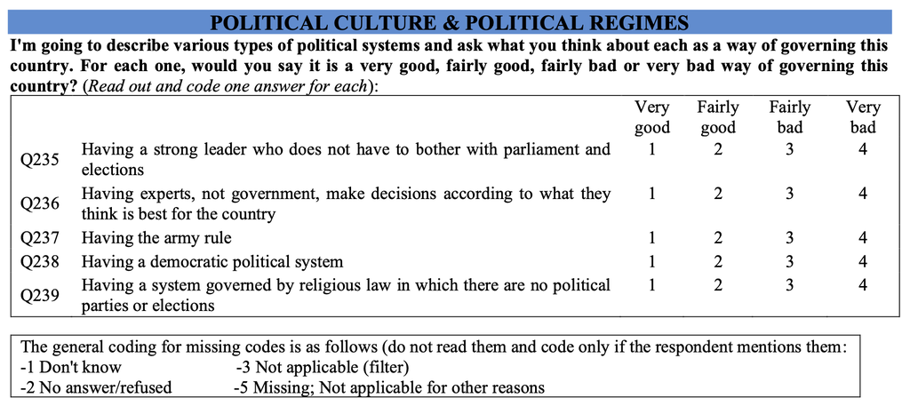

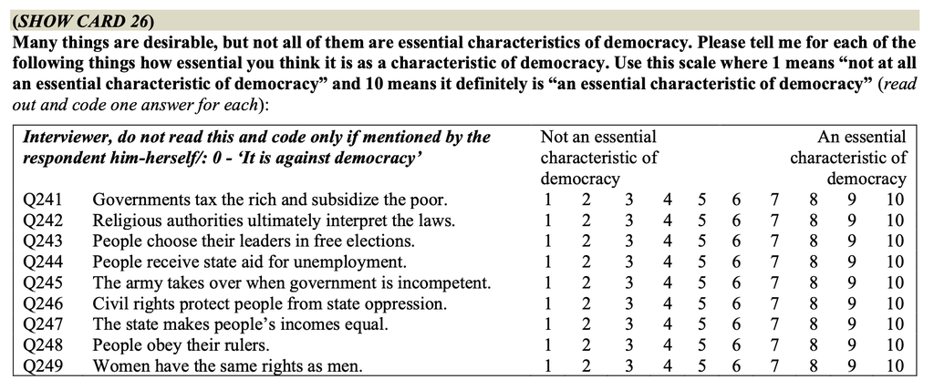

## Using surveys: conditional response

- What is a **battery**?
- What is a **conditional response**? — a question that’s only asked *if* an earlier question was answered a certain way (its “universe” depends on a prior response)
- What is the best way for me to look for topics that interest me?

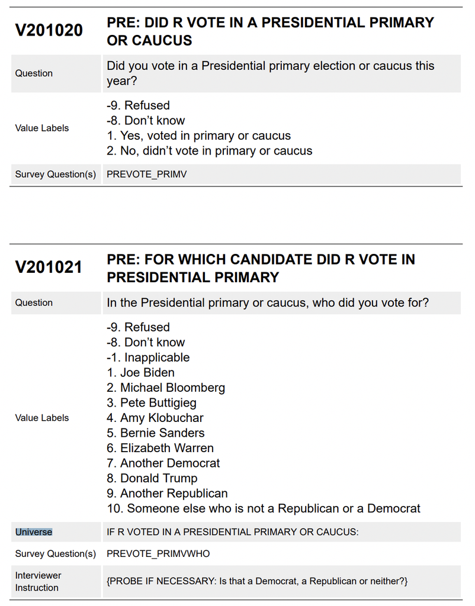

## TL;DR

- **Observations are rows, variables are columns.** Each person interviewed is an observation; each question asked is a variable, with a *label* (`V241177`, `Q243`) and a *value* (the response).
- **ANES and WVS are both individual-level survey data** — but ANES is U.S.-only (2024 Time Series Study, ~5,500 respondents), while WVS spans 64 countries (Wave 7, 2017–2022, ~94,000 respondents) and requires you to justify a country/regional subset.
- **Surveys capture reported identities, circumstances, and opinions/behavior** — not policy content, behavior frequencies, policy impacts, or demographic/temporal facts about a place. A good IV is a respondent characteristic that likely *pre-dates* the opinion you’re explaining.
- **Operationalizing a concept is a judgment call.** How you recode a 7-point scale (into 3 categories? a binary?), or which items you treat as “essential” to democracy, changes your results — the Silberzahn et al. lesson — and the same WVS items look different across countries (e.g. U.S. vs. Germany).
- **A battery is a set of related questions sharing one response scale; a conditional response is a question only asked if an earlier answer triggers it** — both shape how you’ll need to read a codebook.
- **Next step:** select ANES or WVS, identify 1–3 candidate variables for your outcome of interest, and be ready to discuss their strengths and limitations.

## References

American National Election Studies. (2025). *ANES 2024 Time Series Study Full Release*. Dataset and documentation. https://electionstudies.org/data-center/2024-time-series-study/

Haerpfer, C., Inglehart, R., Moreno, A., Welzel, C., Kizilova, K., Diez-Medrano, J., Lagos, M., Norris, P., Ponarin, E., & Puranen, B. (2022). *World Values Survey: Round Seven – Country-Pooled Datafile Version 5.0*. JD Systems Institute; WVSA Secretariat. https://doi.org/10.14281/18241.24

Kellstedt, P. M., Whitten, G. D., & Tuch, S. A. (2022). *The fundamentals of social research*. Cambridge University Press.